# Estimation of Intensity-Duration-Frequency (IDF) Curve through L-Moment method

Emanuele Cordano

2024-10-21

## Intensity-Duration-Frequency Curve (IDF)

- precipitation duration depth ($I \cdot D$) with a fixed return period and a short duration cannot be higher than the depth of an event with a longer duration and the same return period;
- Probability distribution of annual maximum precipitation average intensity maintains constant properties (e.g. parametric definition) for different event time duration only some moments or parameters are scaled with duration.

Therefore annual maxima precipitation are collected from daily or hourly time series; for each duration a probability distributions (e.g. a GEV distribution (Wikipedia contributors (2022))) is fitted through a Maximum Likelihood Method or a L-Moment Method; goodness-of-fit is verified with a statistical test (e.g. Kolgorov-Smirnov test (Marsaglia, Tsang, and Wang (2003))); some moments and/or parameter are scaled with duration through a regression (e.g. a log-LM model); a probability distribution with new moments’ and parameters’ values is estimated for each duration; it can be tested versus original maxima time series. This package uses L-Moment method (Hosking (2019),Cordano (2022)) for the fit of the probability distribution. Recently, Heidari et al. (2020) extend also the concepts of IDF curves to droughts. This aspect can be used in this package but requires further investigations.

## An application with GSOD dataset

Here is an application of use of the package with GSOD precipitation data through *GSODR* package (Sparks, Hengl, and Nelson (2017)) to get (and work with) daily precipitation time series recorded in Bujumbura International Airport, Burundi.

```r
library(GSODR)
library(dplyr)
library(magrittr)
years <- 1973:2023
gsod_rds <- "/home/ecor/local/rpackages/jrc/lmomIDF/inst/ext_data/gsod_643900-99999.rds"
cond <- file.exists(gsod_rds)
if (!cond) {
  gsod <- get_GSOD(years=years,station="643900-99999") ### "643900-99999" "BUJUMBURA INTL"
  saveRDS(gsod,file=gsod_rds)
} else {
  gsod <- readRDS(file=gsod_rds)
}

#####
#####

prec <- gsod %>% dplyr::select(YEARMODA,PRCP,PRCP_ATTRIBUTES) %>%
 mutate(YEARMODA=as.Date(YEARMODA,format="%Y-%m-%d"))

knitr::kable(rbind(head(prec),tail(prec)))
```

| YEARMODA | PRCP | PRCP_ATTRIBUTES |
| --- | --- | --- |
| 1973-06-29 | 0 | G |
| 1974-08-18 | 0 | G |
| 1974-09-06 | 0 | G |
| 1976-09-15 | 0 | I |
| 1976-09-16 | NA | NA |
| 1976-10-07 | 0 | I |
| 2024-09-07 | 0 | G |
| 2024-09-08 | 0 | E |
| 2024-09-09 | 0 | A |
| 2024-09-10 | 0 | G |
| 2024-09-11 | 0 | G |
| 2024-09-12 | 0 | I |

```r
### Dataset preparation
## insertion of rows so that all instants are equidistant (i.e. there is a constant time step)
## inserting any NA values of precipitation intensity


dds <- range(prec$YEARMODA)
## See GSODR documentation
yymmdds <- seq(from=dds[1],to=dds[2],by="day")
prec <- data.table::data.table(YEARMODA=yymmdds) %>% full_join(prec)
```

## Precipitation Time Series

Time series can be visualized as follows:

```r
library(zoo)
```

```r
library(dygraphs)

time <- prec$YEARMODA
precz <- prec$PRCP %>% as.zoo()
index(precz) <- time
main="DAILY PRECIPITATION Vs TIME"
ylab="precipitation [mm/day]"
xlab="time"

dd <- dygraph(precz,main=main,ylab=ylab,xlab=xlab) %>% dyRangeSelector()
dd
```

[interactive chart not shown]

## Annual Maxima for fixed duration

Annual maxima with duration from 1 to 5 days are extracted:

```r
library(lmomIDF)
library(lubridate)


ann.maxima <- annual.agg(x=prec$PRCP,time=prec$YEARMODA,aggr.fun=max,dd=1:5)
### values cannot be -Inf or +Inf
ann.maxima$aggr[ann.maxima$aggr==-Inf] <- NA
###
str(ann.maxima)
```

```
#> tibble [260 × 3] (S3: tbl_df/tbl/data.frame)
#>  $ dd   : num [1:260] 1 1 1 1 1 1 1 1 1 1 ...
#>  $ index: chr [1:260] "1973" "1974" "1975" "1976" ...
#>  $ aggr : num [1:260] 0 0 NA 40.89 5.08 ...
```

```r
###
ann.maxima.z <- ann.maxima %>% reshape2::dcast(index ~ dd)
```

```r
time <- as.numeric(ann.maxima.z$index)
ann.maxima.z <- ann.maxima.z %>% dplyr::select(-index) %>% as.zoo()
time1 <- as.Date("1980-01-01")
year(time1) <- time
index(ann.maxima.z) <- time1


main="MAXIMUM PRECIPITATION INTENSITY Vs TIME"
ylab="precipitation intensity [mm/hr]"
xlab="time"

dda <- dygraph(ann.maxima.z,main=main,ylab=ylab,xlab=xlab) %>% dyRangeSelector()
dda
```

[interactive chart not shown]

## Study Period: 1981-2010

### L-moment estimation

```r
x <- ann.maxima %>% filter(as.numeric(index) %in% 1980:2010)
lmom <- annual.agg.samlmu(x)

head(lmom)
```

```
#>         l_1      l_2       t_3       t_4 dd
#> X1 95.86148 57.08504 0.4418565 0.2240345  1
#> X2 39.41792 24.89031 0.4877735 0.3158361  2
#> X3 28.19768 17.00895 0.4677857 0.3233899  3
#> X4 22.19728 12.93065 0.4373292 0.3250141  4
#> X5 17.49270 10.71173 0.4364365 0.2843202  5
```

### GEV fitting

Through L-Moments , GEV probability distribution parameter were estimated:

```r
para <- annual.agg.pel(distrib="gev",x=x,lmom=lmom)

para$D001
```

```
#>         xi      alpha          k
#> 37.4478897 49.4510344 -0.3839973
#> attr(,"probability_distrib")
#> [1] "gev"
#> attr(,"dd")
#> D001
#>    1
#> attr(,"ks.test")
#>
#>  Asymptotic one-sample Kolmogorov-Smirnov test
#>
#> data:  xval
#> D = 0.095571, p-value = 0.9661
#> alternative hypothesis: two-sided
```

```r
attr(para,"lmom")
```

```
#>         l_1      l_2       t_3       t_4 dd   p.value
#> X1 95.86148 57.08504 0.4418565 0.2240345  1 0.9660770
#> X2 39.41792 24.89031 0.4877735 0.3158361  2 0.9754006
#> X3 28.19768 17.00895 0.4677857 0.3233899  3 0.9984366
#> X4 22.19728 12.93065 0.4373292 0.3250141  4 0.9562970
#> X5 17.49270 10.71173 0.4364365 0.2843202  5 0.9047376
```

### IDF curve (1981-2010)

Regressing logarithms the absolute 1nd and 2rd L-moments with the logarithm of duration, it is obtained:

```r
lmom_idf_1981_2010 <- annual.agg.idf.samlmu(x,lmom=attr(para,"lmom"))
####
summary(attr(lmom_idf_1981_2010,"fit"))
```

```
#>
#> Call:
#> glm(formula = out)
#>
#> Coefficients:
#>             Estimate Std. Error t value Pr(>|t|)
#> (Intercept)  4.50131    0.04319  104.22 1.97e-12 ***
#> lm_orderl_2 -0.50288    0.03927  -12.80 4.11e-06 ***
#> log_dd      -1.03779    0.03455  -30.04 1.17e-08 ***
#> ---
#> Signif. codes:  0 '***' 0.001 '**' 0.01 '*' 0.05 '.' 0.1 ' ' 1
#>
#> (Dispersion parameter for gaussian family taken to be 0.003855926)
#>
#>     Null deviance: 4.139011  on 9  degrees of freedom
#> Residual deviance: 0.026991  on 7  degrees of freedom
#> AIC: -22.769
#>
#> Number of Fisher Scoring iterations: 2
```

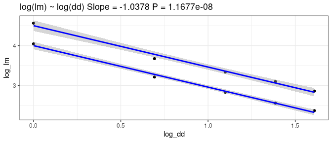

```r
####
attr(lmom_idf_1981_2010,"gg")
```

A IDF relations like $I = a(T) D^{n}$, where $n$ is estimated to be -1, has been assed:

```r
para_idf_1981_2010 <- annual.agg.pel(distrib="gev",x=x,lmom=lmom_idf_1981_2010)

para_idf_1981_2010$D001
```

```
#>         xi      alpha          k
#> 35.1950587 46.1531404 -0.3629869
#> attr(,"probability_distrib")
#> [1] "gev"
#> attr(,"dd")
#> D001
#>    1
#> attr(,"ks.test")
#>
#>  Asymptotic one-sample Kolmogorov-Smirnov test
#>
#> data:  xval
#> D = 0.10957, p-value = 0.9021
#> alternative hypothesis: two-sided
```

```r
attr(para_idf_1981_2010,"lmom")
```

```
#>          l_1      l_2       t_3       t_4 dd   p.value
#> 1   87.33142 51.29078 0.4256057 0.2444445  1 0.9020794
#> 1.1 43.66571 25.64539 0.4256057 0.2444445  2 0.8463237
#> 1.2 29.11047 17.09693 0.4256057 0.2444445  3 0.9754389
#> 1.3 21.83285 12.82269 0.4256057 0.2444445  4 0.9519037
#> 1.4 17.46628 10.25816 0.4256057 0.2444445  5 0.7649818
```

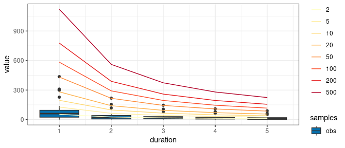

```r
set.seed(560)
rt <- c(2,5,10,20,50,100,200,500)
f  <- 1-1/rt
##f=c(0.5,0.8,0.9,0.95,0.98,0.99,0.999,0.9999)

out_qua_1981_2010 <- annual.agg.qua(f=f,para=para_idf_1981_2010,remove_distrib_from_boxplot=TRUE)
attr(out_qua_1981_2010,"idf")
```

And the analogous plot resenting precipitation depth with DDF (Depth-Duration-Frequency) curve :

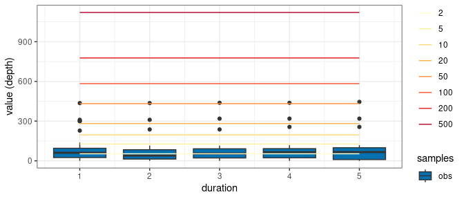

```r
attr(out_qua_1981_2010,"ddf")
```

### L-moment estimation

```r
x <- ann.maxima %>% filter(as.numeric(index) %in% 1980:2020)
lmom <- annual.agg.samlmu(x)

head(lmom)
```

```
#>         l_1      l_2       t_3       t_4 dd
#> X1 95.81973 53.97800 0.4180556 0.1978264  1
#> X2 41.98868 24.50337 0.4424298 0.2575864  2
#> X3 29.37949 16.63331 0.4347956 0.2606851  3
#> X4 22.89667 12.56866 0.4118726 0.2647797  4
#> X5 18.12182 10.48793 0.4087037 0.2330300  5
```

### GEV fitting

Through the L-Moments , GEV probability distribution parameters are estimated as follows:

```r
para <- annual.agg.pel(distrib="gev",x=x,lmom=lmom)

para$D001
```

```
#>         xi      alpha          k
#> 41.1319563 49.4180066 -0.3531512
#> attr(,"probability_distrib")
#> [1] "gev"
#> attr(,"dd")
#> D001
#>    1
#> attr(,"ks.test")
#>
#>  Asymptotic one-sample Kolmogorov-Smirnov test
#>
#> data:  xval
#> D = 0.10267, p-value = 0.8302
#> alternative hypothesis: two-sided
```

```r
attr(para,"lmom")
```

```
#>         l_1      l_2       t_3       t_4 dd   p.value
#> X1 95.81973 53.97800 0.4180556 0.1978264  1 0.8302168
#> X2 41.98868 24.50337 0.4424298 0.2575864  2 0.9730208
#> X3 29.37949 16.63331 0.4347956 0.2606851  3 0.9754454
#> X4 22.89667 12.56866 0.4118726 0.2647797  4 0.9541173
#> X5 18.12182 10.48793 0.4087037 0.2330300  5 0.9633267
```

Regressing the logarithms the absolute 1nd and 2rd L-moments with the logarithm of duration, it is obtained:

```r
lmom_idf_1991_2020 <- annual.agg.idf.samlmu(x,lmom=attr(para,"lmom"))
####
summary(attr(lmom_idf_1991_2020,"fit"))
```

```
#>
#> Call:
#> glm(formula = out)
#>
#> Coefficients:
#>             Estimate Std. Error t value Pr(>|t|)
#> (Intercept)  4.51919    0.03149  143.53 2.10e-13 ***
#> lm_orderl_2 -0.56561    0.02863  -19.75 2.13e-07 ***
#> log_dd      -1.02093    0.02518  -40.54 1.45e-09 ***
#> ---
#> Signif. codes:  0 '***' 0.001 '**' 0.01 '*' 0.05 '.' 0.1 ' ' 1
#>
#> (Dispersion parameter for gaussian family taken to be 0.002049279)
#>
#>     Null deviance: 4.181755  on 9  degrees of freedom
#> Residual deviance: 0.014345  on 7  degrees of freedom
#> AIC: -29.091
#>
#> Number of Fisher Scoring iterations: 2
```

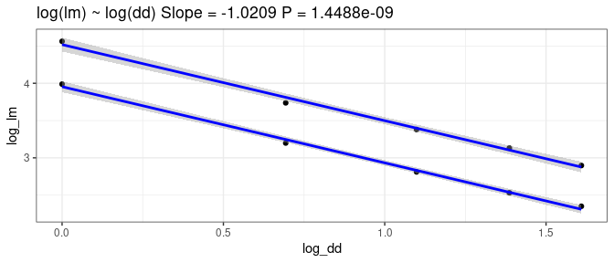

```r
####
attr(lmom_idf_1991_2020,"gg")
```

A IDF relations like $I = a(T) D^{n}$, where $n$ is estimated to be -1, is then assessed:

```r
para_idf_1991_2020 <- annual.agg.pel(distrib="gev",x=x,lmom=lmom_idf_1991_2020)

para_idf_1991_2020$D001
```

```
#>         xi      alpha          k
#> 39.6713633 47.3870072 -0.3344398
#> attr(,"probability_distrib")
#> [1] "gev"
#> attr(,"dd")
#> D001
#>    1
#> attr(,"ks.test")
#>
#>  Asymptotic one-sample Kolmogorov-Smirnov test
#>
#> data:  xval
#> D = 0.11254, p-value = 0.7367
#> alternative hypothesis: two-sided
```

```r
attr(para_idf_1991_2020,"lmom")
```

```
#>          l_1      l_2       t_3       t_4 dd   p.value
#> 1   90.12700 50.12862 0.4037926 0.2140429  1 0.7367492
#> 1.1 45.06350 25.06431 0.4037926 0.2140429  2 0.6824120
#> 1.2 30.04233 16.70954 0.4037926 0.2140429  3 0.9384156
#> 1.3 22.53175 12.53215 0.4037926 0.2140429  4 0.9143840
#> 1.4 18.02540 10.02572 0.4037926 0.2140429  5 0.9480266
```

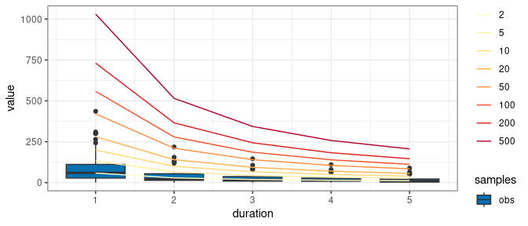

```r
set.seed(560)
rt <- c(2,5,10,20,50,100,200,500)
f  <- 1-1/rt
##f=c(0.5,0.8,0.9,0.95,0.98,0.99,0.999,0.9999)
out_qua_1991_2020 <- annual.agg.qua(f=f,para=para_idf_1991_2020,remove_distrib_from_boxplot=TRUE)
attr(out_qua_1991_2020,"idf")
```

And the analogous plot resenting precipitation depth with DDF (Depth-Duration-Frequacy) curve :

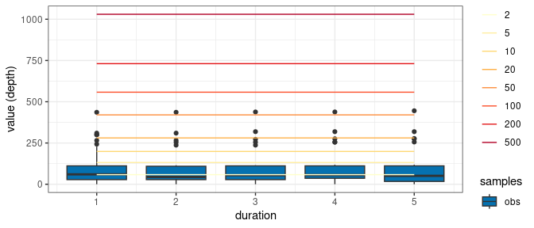

```r
attr(out_qua_1991_2020,"ddf")
```

## Comparison between 1981-2010 and 1991-2020

```r
qua_1991_2020 <- out_qua_1991_2020
qua_1981_2010 <- out_qua_1981_2010

attr(out_qua_1981_2010,"n_idf")
```

```
#> [1] -1
```

```r
attr(out_qua_1991_2020,"n_idf")
```

```
#> [1] -1
```

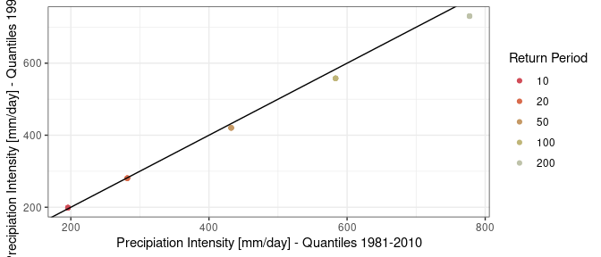

```r
qua_1981_2010$a <- qua_1981_2010$aggr/(qua_1981_2010$dd^attr(out_qua_1981_2010,"n_idf"))
qua_1991_2020$a <- qua_1991_2020$aggr/(qua_1991_2020$dd^attr(out_qua_1991_2020,"n_idf"))
#####
qua_1981_2010 <- qua_1981_2010 %>% dplyr::select(-aggr)
qua_1991_2020 <- qua_1991_2020 %>% dplyr::select(-aggr)
#####

names(qua_1981_2010)[names(qua_1981_2010)=="a"] <- "a_1981_2010"
names(qua_1991_2020)[names(qua_1991_2020)=="a"] <- "a_1991_2020"
#####


# > ggplot()+geom_point(data=qua_both,aes(x=aggr_1981_2010,y=aggr_1991_2010))
# Error in FUN(X[[i]], ...) : object 'aggr_1991_2010' not found
# > ggplot()+geom_point(data=qua_both,aes(x=aggr_1981_2010,y=aggr_1991_2020))
# > ggplot()+geom_point(data=qua_both,aes(x=aggr_1981_2010,y=aggr_1991_2020,group=dd))
# > ggplot()+geom_point(data=qua_both,aes(x=aggr_1981_2010,y=aggr_1991_2020,group=dd,fill=dd))
# > ggplot()+geom_point(data=qua_both,aes(x=aggr_1981_2010,y=aggr_1991_2020,group=dd,color=factor(dd)))
# >
#####
#qua_both <- full_join(qua_1981_2010,qua_1991_2020)
qua_both <- full_join(qua_1981_2010,qua_1991_2020)
#####
library(ggplot2)
library(RColorBrewer)

###
qua_both$rt <- round(1/(1-qua_both$f))
###
qua_both <- qua_both %>% dplyr::filter(rt %in% c(10,20,50,100,200))
##gg <- ggplot()+geom_point(data=qua_both,aes(x=a_1981_2010,y=a_1991_2020,color=factor(f)))## Probability
gg <- ggplot()+geom_point(data=qua_both,aes(x=a_1981_2010,y=a_1991_2020,color=factor(rt)))## Return Period
gg <- gg+xlab("Precipiation Intensity [mm/day] - Quantiles 1981-2010")+ylab("Precipiation Intensity [mm/day] - Quantiles 1991-2020")+theme_bw()+geom_abline()
###
col1 <- brewer.pal(name="YlGnBu",n=length(unique(qua_both$f))) %>% col2rgb()
col2 <- brewer.pal(name="YlOrRd",n=length(unique(qua_both$f))) %>% rev() %>% col2rgb()
coll <- (col1*0.3+col2*0.7)/255
##coll[,] <- as.integer(coll[,])
colz <- rgb(red=coll["red",],green=coll["green",],blue=coll["blue",],maxColorValue = 1)

##YlOrRd
##gg <- gg+scale_color_manual(name="Probability",values=colz) ## "Probability"
gg <- gg+scale_color_manual(name="Return Period",values=colz) ## Return Periods
gg
```

## Conclusions

Finally, a vignette about a proper use of **lmomIDF** package has been shown. The user can make his/her own quantitative assessments of the results and draw on the chunks of code reported to tailor what the package can offer to his/her own needs.

## Further Readings on Similar Topic

Similar reading on which outcomes can be compared:

- https://www.gis-blog.com/eva-intro-2/ ;
- https://climatedata.ca/resource/idf-curves-101/ ;
- https://en.wikipedia.org/wiki/Intensity-duration-frequency_curve ;
- https://www.engr.colostate.edu/~ramirez/ce_old/classes/cive322-Ramirez/IDF-Procedure.pdf ;
- https://www.mitma.gob.es/recursos_mfom/0610300.pdf (in Spanish);
- http://www.comune.laspezia.it/export/sites/SPEZIAnet/Aree_tematiche/Ambiente/Energia/Piano-dazione-locale-di-adattamento.pdf or https://interreg-maritime.eu/documents/374720/6676234/ADAPT_piano_locale_PP08_IT.pdf/40e2289f-ab37-4187-8c73-cf3eab8737dc?t=1581354178721 (from https://interreg-maritime.eu/web/adapt/-/piani-locali-di-adattamento , in Italian).

The list and URLs and/or references will be further updated.

## References

Cordano, Emanuele. 2022. *lmomPi: (Precipitation) Frequency Analysis and Variability with l-Moments from ’Lmom’*. https://CRAN.R-project.org/package=lmomPi.

Courty, Laurent G, Robert L Wilby, John K Hillier, and Louise J Slater. 2019. “Intensity-Duration-Frequency Curves at the Global Scale.” *Environmental Research Letters* 14 (8): 084045. https://doi.org/10.1088/1748-9326/ab370a.

Heidari, Hadi, Mazdak Arabi, Mahshid Ghanbari, and Travis Warziniack. 2020. “A Probabilistic Approach for Characterization of Sub-Annual Socioeconomic Drought Intensity-Duration-Frequency (IDF) Relationships in a Changing Environment.” *Water* 12 (6). https://doi.org/10.3390/w12061522.

Hosking, J. R. M. 2019. *L-Moments*. https://CRAN.R-project.org/package=lmom.

Koutsoyiannis, Demetris, Demosthenes Kozonis, and Alexandros Manetas. 1998. “A Mathematical Framework for Studying Rainfall Intensity-Duration-Frequency Relationships.” *Journal of Hydrology* 206 (1): 118–35. https://doi.org/https://doi.org/10.1016/S0022-1694(98)00097-3.

Markiewicz, Iwona. 2021. “Depth&ndash;duration&ndash;frequency Relationship Model of Extreme Precipitation in Flood Risk Assessment in the Upper Vistula Basin.” *Water* 13 (23). https://doi.org/10.3390/w13233439.

Marsaglia, George, Wai Wan Tsang, and Jingbo Wang. 2003. “Evaluating Kolmogorov’s Distribution.” *Journal of Statistical Software* 8 (18): 1–4. https://doi.org/10.18637/jss.v008.i18.

Sparks, Adam H, Tomislav Hengl, and Andrew Nelson. 2017. “GSODR: Global Summary Daily Weather Data in r.” *The Journal of Open Source Software* 2 (10). https://doi.org/10.21105/joss.00177.

Sun, Yabin, Dadiyorto Wendi, Dong Eon Kim, and Shie-Yui Liong. 2019. “Deriving Intensity–Duration–Frequency (IDF) Curves Using Downscaled in Situ Rainfall Assimilated with Remote Sensing Data.” *Geoscience Letters* 6 (1): 17. https://doi.org/10.1186/s40562-019-0147-x.

Wikipedia contributors. 2022. “Generalized Extreme Value Distribution — Wikipedia, the Free Encyclopedia.” https://en.wikipedia.org/w/index.php?title=Generalized_extreme_value_distribution&oldid=1118970041.